# HW9_6306

yleung

March 9, 2019

#### R Libraries

```r
library(dplyr)
library(tidyr)
library(ggplot2)
library(grid)
library(gridExtra)
library(GGally)
library(maps)
library(openintro)
library(mosaic)
library(kableExtra)
library(stringr)
library(stringi)
```

```r
Beer<-read.csv(file = 'C:\\Users\\Yat\\Documents\\MSDS\\MSDS 6306 Doing Data Science\\Unit 9\\Beers.csv', header=TRUE, sep=",")

Brewery<-read.csv(file = 'C:\\Users\\Yat\\Documents\\MSDS\\MSDS 6306 Doing Data Science\\Unit 9\\Breweries.csv', header=TRUE, sep=",")
```

#### Part A. Clean and prepare the data

```r
#Merge Beer & Brewery data frames by the brewery id
Brewery_Beer<-merge(Beer, Brewery,by.x = "Brewery_id", by.y = "Brew_ID")

#Rename the Header of the Beer Name and Brewery Name after merging
colnames(Brewery_Beer)[2]<-"Beer_Name"
colnames(Brewery_Beer)[8]<-"Brewery_Name"

#To get rid of spaces
Brewery_Beer["State"] <- str_trim(Brewery_Beer$State,"left")
#Brewery_Beer

#Subsetting CO and TX into beerCOTX df
beerCOTX<-Brewery_Beer%>%select(everything())%>%filter(State %in% c("CO", "TX"))
#beerCOTX

#Remove N/A from beerCOTX
beerCOTX<-beerCOTX%>%select(everything())%>%na.omit(beerCOTX$IBU)

#Order beerCOTX by IBU in ascending order
beerCOTX<-beerCOTX[order(beerCOTX$IBU),]
```

#### Part B. Plot ABV v. IBU for Colorado and Texas (facet the 2 plots)

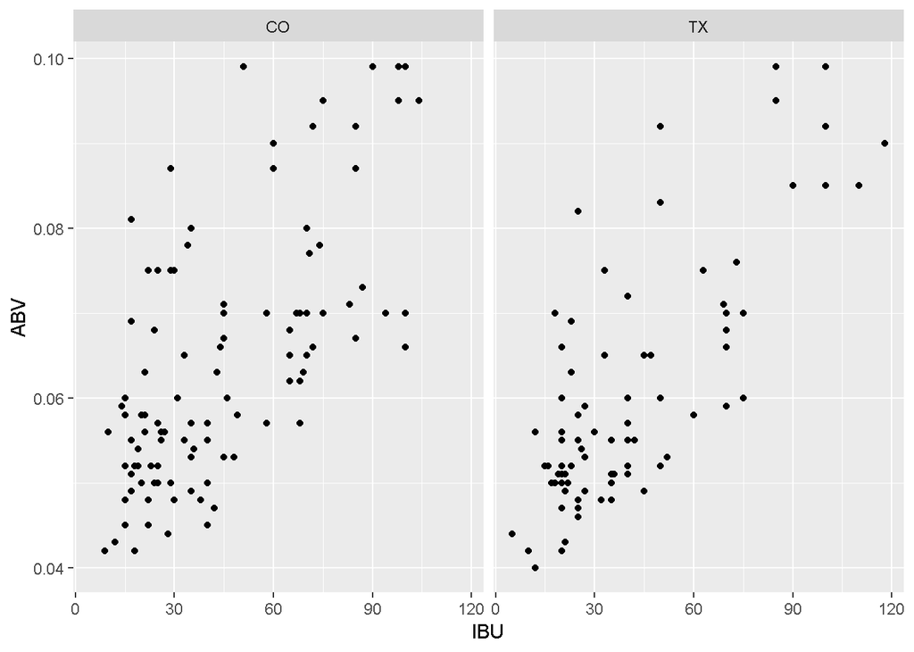

```r
#Plot the ABV vs IBU
sp <- ggplot(beerCOTX, aes(x=IBU, y=ABV)) + geom_point()

#Divide by states, in the horizontal direction
sp + facet_grid(. ~ beerCOTX$State)
```

#### Part C. Data Modeling

```r
#Fit simple linear regression for each state
lm.CO.fit <-lm(ABV~IBU,data=subset(beerCOTX,beerCOTX$State=="CO"))
lm.CO.fit
```

```
##
## Call:
## lm(formula = ABV ~ IBU, data = subset(beerCOTX, beerCOTX$State ==
##     "CO"))
##
## Coefficients:
## (Intercept)          IBU
##   0.0474013    0.0003676
```

```r
lm.TX.fit <-lm(ABV~IBU,data=subset(beerCOTX,beerCOTX$State=="TX"))
lm.TX.fit
```

```
##
## Call:
## lm(formula = ABV ~ IBU, data = subset(beerCOTX, beerCOTX$State ==
##     "TX"))
##
## Coefficients:
## (Intercept)          IBU
##   0.0434737    0.0004172
```

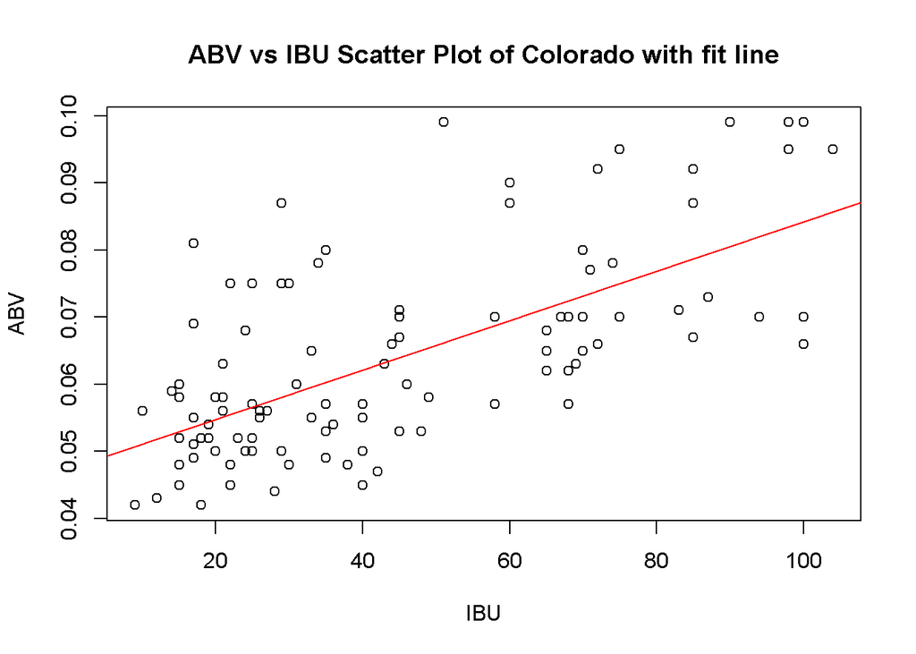

```r
#Scatter plot for each state
#Scatter Plot of Colorado with fit line
plot(ABV~IBU, data=subset(beerCOTX,beerCOTX$State=="CO"),main="ABV vs IBU Scatter Plot of Colorado with fit line")
abline(lm.CO.fit, col="red") # regression line (y~x)
```

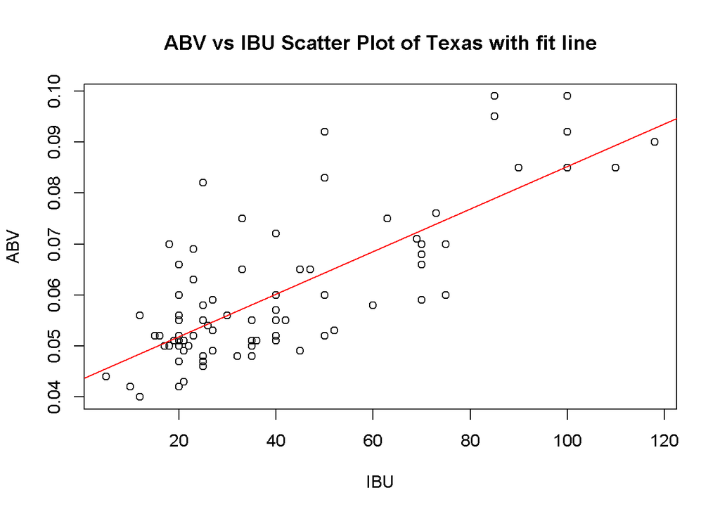

```r
#Scatter Plot of Texas with fit line
plot(ABV~IBU, data=subset(beerCOTX,beerCOTX$State=="TX"),main="ABV vs IBU Scatter Plot of Texas with fit line")
abline(lm.TX.fit, col="red") # regression line (y~x)
```

```r
#Assumptions
#Colorado
beerCOTX %>%select(ABV,State)%>% filter(State=="CO")%>%summary(ABV)
```

```
##       ABV             State
##  Min.   :0.04200   Length:146
##  1st Qu.:0.05300   Class :character
##  Median :0.06500   Mode  :character
##  Mean   :0.06484
##  3rd Qu.:0.07075
##  Max.   :0.09900
```

```r
beerCOTX %>%select(IBU,State)%>% filter(State=="CO")%>%summary(IBU)
```

```
##       IBU            State
##  Min.   :  9.00   Length:146
##  1st Qu.: 24.25   Class :character
##  Median : 40.00   Mode  :character
##  Mean   : 47.43
##  3rd Qu.: 66.50
##  Max.   :104.00
```

```r
beerCOTX %>%select(ABV,State)%>% filter(State=="CO")%>%summary(ABV)
```

```
##       ABV             State
##  Min.   :0.04200   Length:146
##  1st Qu.:0.05300   Class :character
##  Median :0.06500   Mode  :character
##  Mean   :0.06484
##  3rd Qu.:0.07075
##  Max.   :0.09900
```

```r
beerCOTX %>%select(IBU,State)%>% filter(State=="CO")%>%summary(IBU)
```

```
##       IBU            State
##  Min.   :  9.00   Length:146
##  1st Qu.: 24.25   Class :character
##  Median : 40.00   Mode  :character
##  Mean   : 47.43
##  3rd Qu.: 66.50
##  Max.   :104.00
```

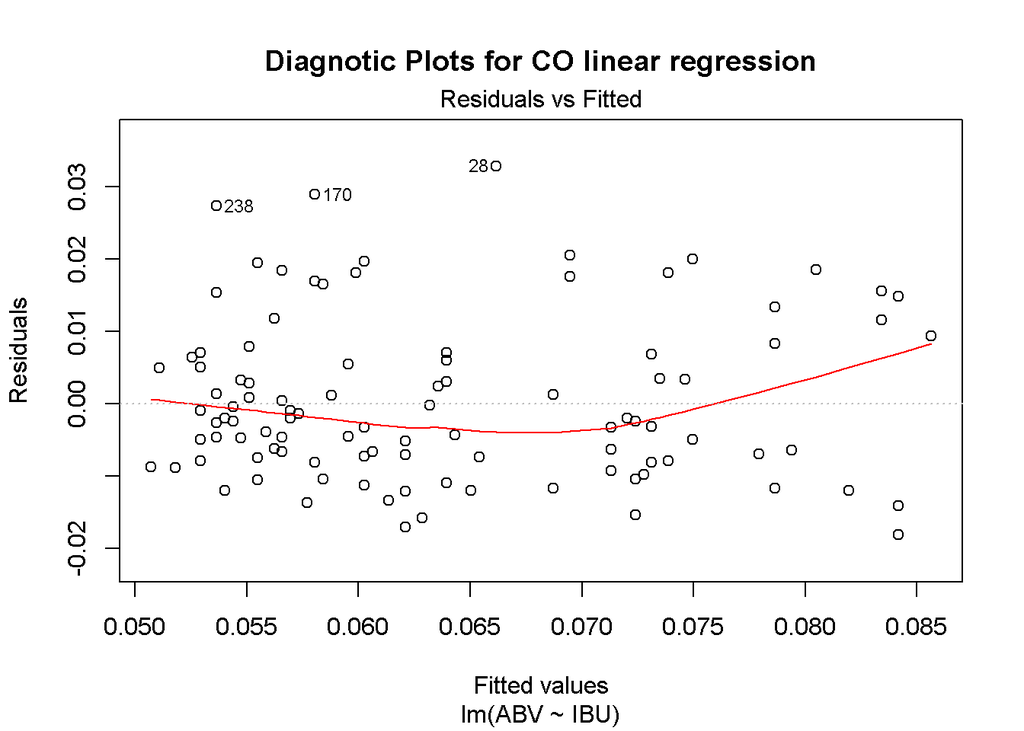

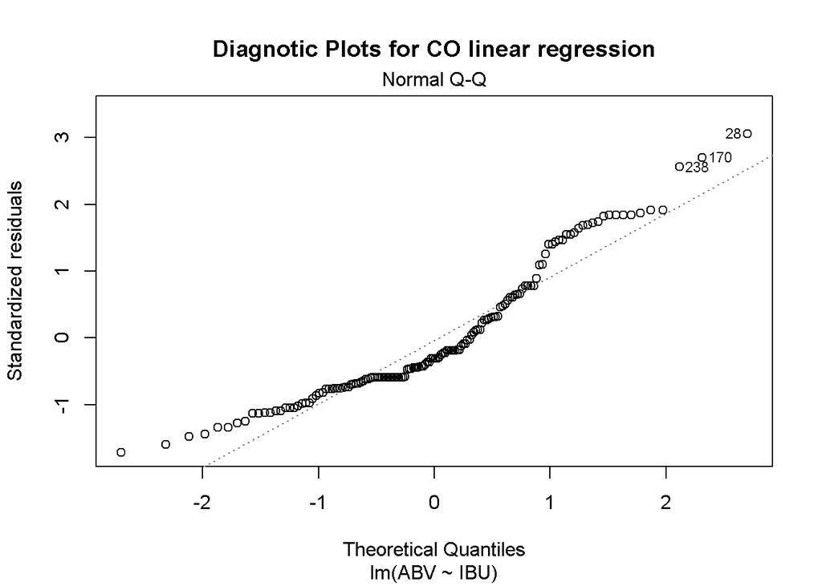

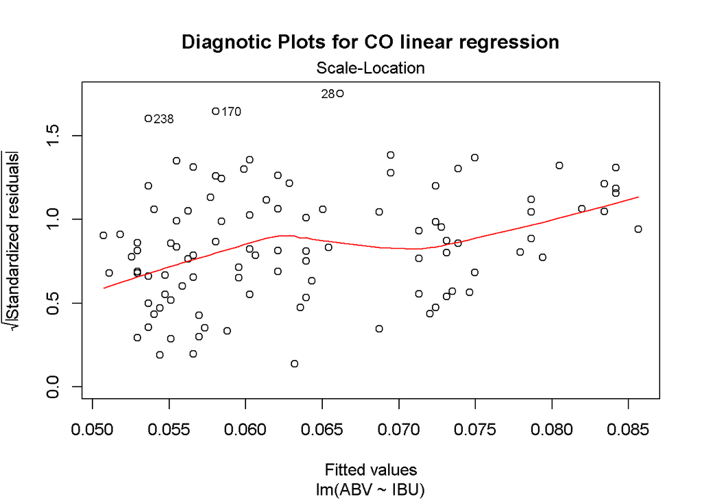

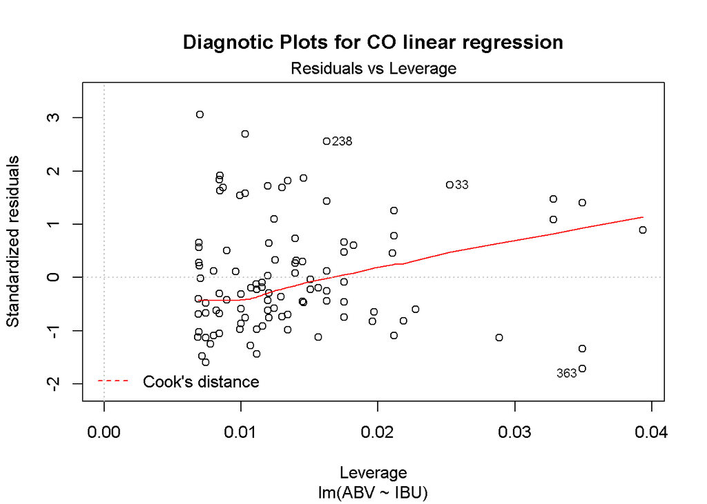

```r
plot(lm.CO.fit,main="Diagnotic Plots for CO linear regression")
```

```r
#

#Texas
beerCOTX %>%select(ABV,State)%>% filter(State=="TX")%>%summary(ABV)
```

```
##       ABV             State
##  Min.   :0.04000   Length:89
##  1st Qu.:0.05000   Class :character
##  Median :0.05500   Mode  :character
##  Mean   :0.06033
##  3rd Qu.:0.06800
##  Max.   :0.09900
```

```r
beerCOTX %>%select(IBU,State)%>% filter(State=="TX")%>%summary(IBU)
```

```
##       IBU            State
##  Min.   :  5.00   Length:89
##  1st Qu.: 21.00   Class :character
##  Median : 33.00   Mode  :character
##  Mean   : 40.39
##  3rd Qu.: 50.00
##  Max.   :118.00
```

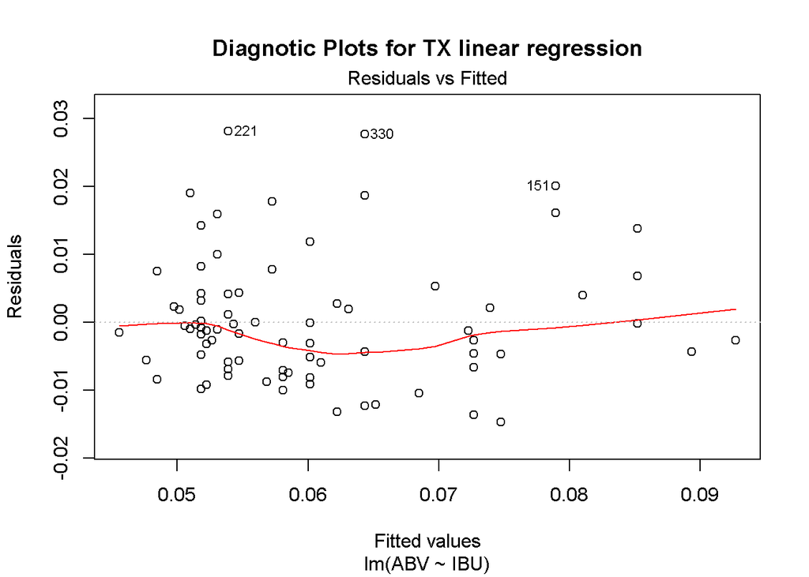

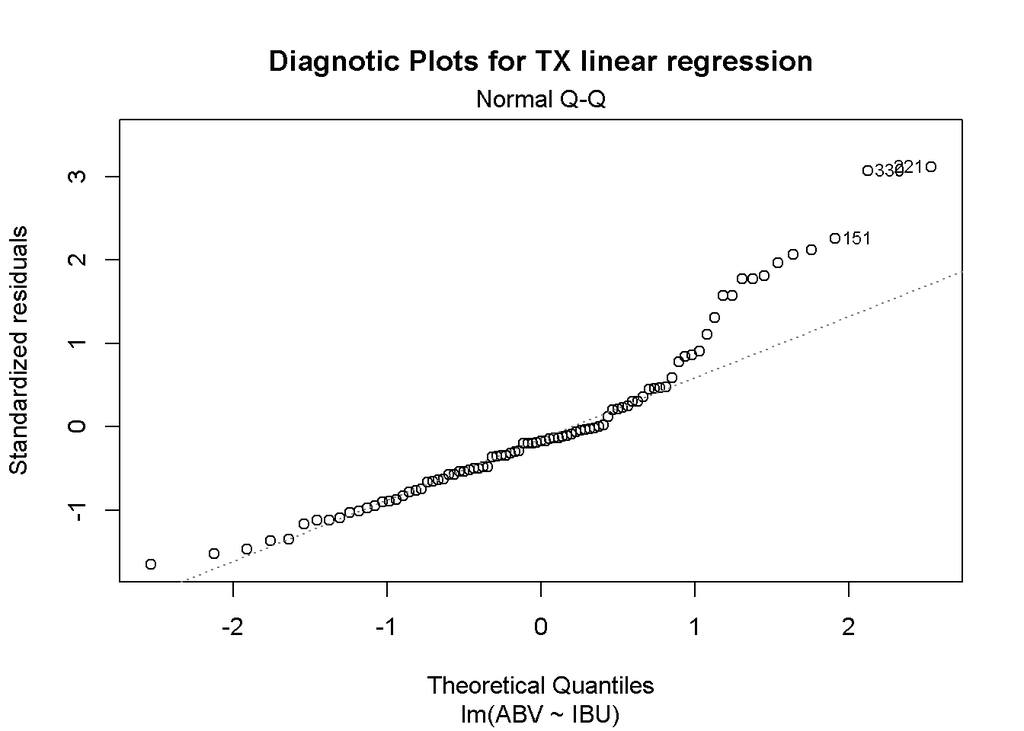

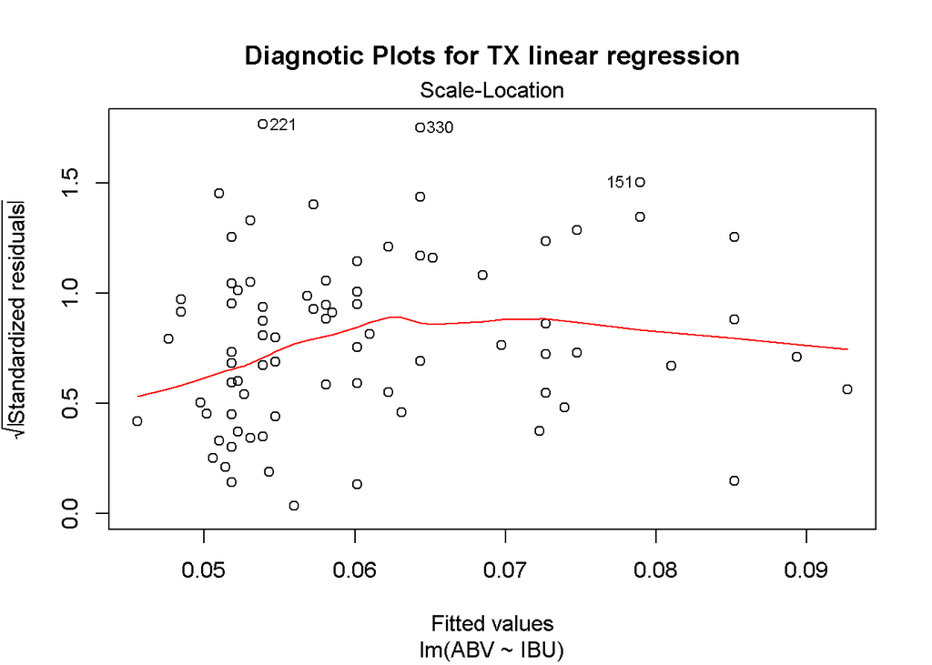

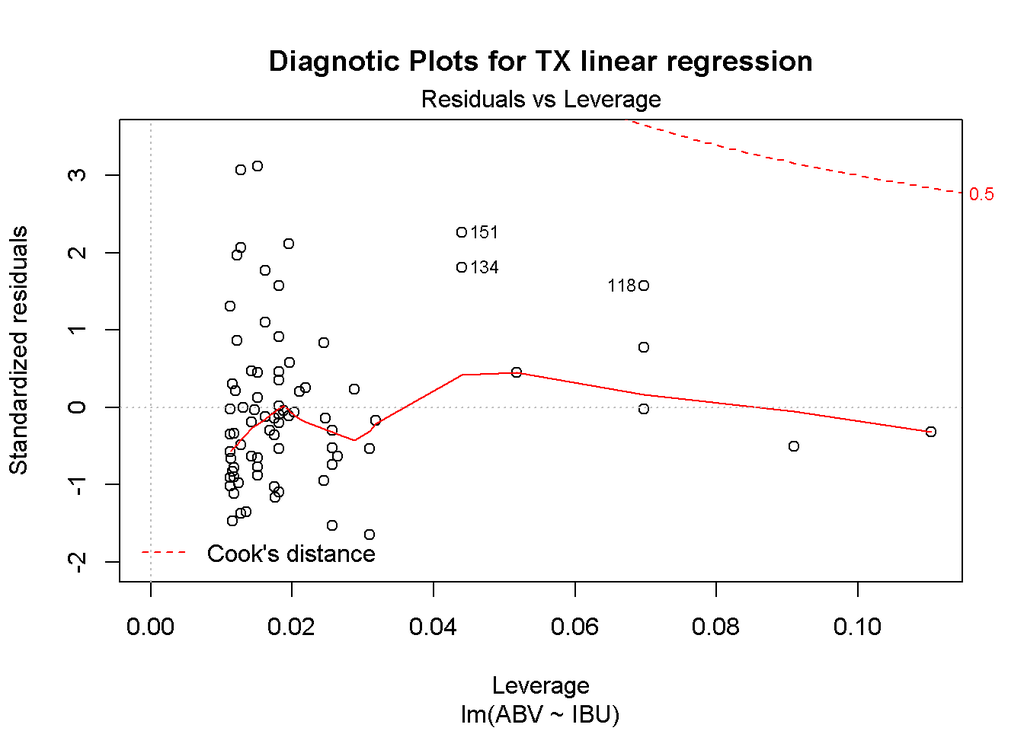

```r
plot(lm.TX.fit,main="Diagnotic Plots for TX linear regression")
```

**Data Normality Assumption:**

**Residual vs Fitted**

For Colorado,there points were randomly spread out. Same for Texas.

**Standardized Residual vs Normal QQ**

For Colorado, most points fall in a straight line, there were a few outliers and slight curvature but with the amount of observation, this data set can be considered to be normally distributed. For Texas, most points fall in a straight line, there was a curvature towards the upper end of the plot but with the amount of observation, this data set can be considered to be normally distributed

**SQRT(|Standardized Residuals|) vs Fitted Value**

**Standardized Residual vs Leverage**

#### Part D. Model Inference

```r
#Simple Linear Regression model summary and confidence intervals for Colorado
summary(lm.CO.fit)
```

```
##
## Call:
## lm(formula = ABV ~ IBU, data = subset(beerCOTX, beerCOTX$State ==
##     "CO"))
##
## Residuals:
##       Min        1Q    Median        3Q       Max
## -0.018158 -0.007266 -0.003293  0.006453  0.032853
##
## Coefficients:
##              Estimate Std. Error t value Pr(>|t|)
## (Intercept) 4.740e-02  1.856e-03   25.54   <2e-16 ***
## IBU         3.676e-04  3.432e-05   10.71   <2e-16 ***
## ---
## Signif. codes:  0 '***' 0.001 '**' 0.01 '*' 0.05 '.' 0.1 ' ' 1
##
## Residual standard error: 0.01077 on 144 degrees of freedom
## Multiple R-squared:  0.4433, Adjusted R-squared:  0.4395
## F-statistic: 114.7 on 1 and 144 DF,  p-value: < 2.2e-16
```

```r
confint(lm.CO.fit)
```

```
##                   2.5 %       97.5 %
## (Intercept) 0.043732505 0.0510700022
## IBU         0.000299726 0.0004354124
```

```r
#Simple Linear Regression model summary and confidence intervals for Texas
summary(lm.TX.fit)
```

```
##
## Call:
## lm(formula = ABV ~ IBU, data = subset(beerCOTX, beerCOTX$State ==
##     "TX"))
##
## Residuals:
##       Min        1Q    Median        3Q       Max
## -0.014764 -0.005738 -0.001560  0.003182  0.028096
##
## Coefficients:
##              Estimate Std. Error t value Pr(>|t|)
## (Intercept) 4.347e-02  1.772e-03   24.54   <2e-16 ***
## IBU         4.172e-04  3.683e-05   11.33   <2e-16 ***
## ---
## Signif. codes:  0 '***' 0.001 '**' 0.01 '*' 0.05 '.' 0.1 ' ' 1
##
## Residual standard error: 0.009078 on 87 degrees of freedom
## Multiple R-squared:  0.596,  Adjusted R-squared:  0.5914
## F-statistic: 128.3 on 1 and 87 DF,  p-value: < 2.2e-16
```

```r
confint(lm.TX.fit)
```

```
##                   2.5 %       97.5 %
## (Intercept) 0.039952379 0.0469949413
## IBU         0.000344007 0.0004903987
```

**Model Inference:**

For Colorado:

$\widehat{ABV}_{Colordo}$ = 0.0474013 + 0.0003676* IBU

For Texas:

$\widehat{ABV}_{Texas}$ = 0.0434737 + 0.0004172* IBU

**Question: Is there evidence that the relationship between ABV and IBU is significantly different for Texas and Colorado beers?**

The 95% CI for Colorado and Texas intercepts,$\beta_{0}$, were approximately (0.04,0.05) and the 95%CI of IBU,$\beta_{1}$, for both data sets were (0003,0.0004) for Colorado and (0003,0.0005). There was no significant evidence to believe that the ABV-IBU relationship was different between Texas and Colorado.

#### Part E. Compare two competing models: External Cross Validation

```r
#square IBU and add this to beerCOTX
beerCOTX$IBU2<-(beerCOTX$IBU)^2
#Print top 6 rows beerCOTX
head(beerCOTX)
```

```
##     Brewery_id             Beer_Name Beer_ID   ABV IBU
## 58          67    Yo Soy Un Berliner    2520 0.044   5
## 149        129 18th Anniversary Gose    2370 0.044   5
## 294        392           Agave Wheat    1522 0.042   9
## 19          38          White Rascal     108 0.056  10
## 56          67               Rye Wit    2522 0.042  10
## 225        188             Lobo Lito    2238 0.040  12
##                       Style Ounces               Brewery_Name
## 58       Berliner Weissbier     12   Freetail Brewing Company
## 149                    Gose     12   Real Ale Brewing Company
## 294 American Pale Wheat Ale     12       Breckenridge Brewery
## 19                  Witbier     12      Avery Brewing Company
## 56                  Witbier     12   Freetail Brewing Company
## 225             Light Lager     12 Pedernales Brewing Company
##               City State IBU2
## 58     San Antonio    TX   25
## 149         Blanco    TX   25
## 294         Denver    CO   81
## 19         Boulder    CO  100
## 56     San Antonio    TX  100
## 225 Fredericksburg    TX  144
```

```r
#Split beerCOTX into Colorado and Texas
Colorado<-beerCOTX%>%select(everything())%>%filter(State=="CO")
Texas<-beerCOTX%>%select(everything())%>%filter(State=="TX")

#Initialize empty data frames for TrainingCO, TestCO, TrainingTX, TestTX
TrainingCO = data.frame()
TestCO = data.frame()
TrainingTX = data.frame()
TestTX = data.frame()

#Divide into training and test set ... this one is 60% training 40% test
train_perc = .6

#Indices for each data set
train_indices_CO = sample(seq(1,nrow(Colorado),by = 1), train_perc*nrow(Colorado))
train_indices_TX = sample(seq(1,nrow(Texas),by = 1), train_perc*nrow(Texas))

#Train and Test sets for Colorado
TrainingCO = Colorado[train_indices_CO,]
TestCO = Colorado[-train_indices_CO,]

#Train and Test sets for Texas
TrainingTX = Texas[train_indices_TX,]
TestTX = Texas[-train_indices_TX,]

#ASE holders for each state, Deg 1 Model
ASEholderTrainingCO = c()
ASEholderTestCO = c()
ASeholderTrainingTX = c()
ASeholderTestTX = c()

#Fit the Deg 1 Model for Colorado
TrainingCO.Fit = lm(ABV~IBU, data = TrainingCO)
#Traning Data Fit Summary
summary(TrainingCO.Fit)
```

```
##
## Call:
## lm(formula = ABV ~ IBU, data = TrainingCO)
##
## Residuals:
##       Min        1Q    Median        3Q       Max
## -0.014656 -0.006495 -0.003607  0.004204  0.033407
##
## Coefficients:
##              Estimate Std. Error t value Pr(>|t|)
## (Intercept) 4.740e-02  2.295e-03  20.659  < 2e-16 ***
## IBU         3.567e-04  4.422e-05   8.066 4.16e-12 ***
## ---
## Signif. codes:  0 '***' 0.001 '**' 0.01 '*' 0.05 '.' 0.1 ' ' 1
##
## Residual standard error: 0.01034 on 85 degrees of freedom
## Multiple R-squared:  0.4336, Adjusted R-squared:  0.4269
## F-statistic: 65.06 on 1 and 85 DF,  p-value: 4.165e-12
```

```r
# Predictions of the model on the Colorado data that were used to fit the model.
predsTrainingCO = predict(TrainingCO.Fit)
TrainingCO.Fit$preds = predsTrainingCO

# Predictions of the model on the Colorado data that were NOT used to fit the model.
predsTestCO = predict(TrainingCO.Fit, newdata = TestCO)
TestCO$preds = predsTestCO

# Calculation of the ASE for the Colorado training set
ASEholderTrainingCO = sum((predsTrainingCO - TrainingCO$ABV)^2)/(length(TrainingCO$ABV))
# Calculation of the ASE for the Colorado Test set
ASEholderTestCO = sum((predsTestCO - TestCO$ABV)^2)/(length(TestCO$ABV))

ASEholderTrainingCO
```

```
## [1] 0.0001044739
```

```r
ASEholderTestCO
```

```
## [1] 0.0001299856
```

```r
#Fit the Deg 1 Model for Texas
TrainingTX.Fit = lm(ABV~IBU, data = TrainingTX)
#Traning Data Fit Summary
summary(TrainingTX.Fit)
```

```
##
## Call:
## lm(formula = ABV ~ IBU, data = TrainingTX)
##
## Residuals:
##       Min        1Q    Median        3Q       Max
## -0.013328 -0.005979 -0.001238  0.002706  0.027425
##
## Coefficients:
##              Estimate Std. Error t value Pr(>|t|)
## (Intercept) 4.210e-02  2.382e-03  17.674  < 2e-16 ***
## IBU         4.494e-04  5.203e-05   8.637 1.49e-11 ***
## ---
## Signif. codes:  0 '***' 0.001 '**' 0.01 '*' 0.05 '.' 0.1 ' ' 1
##
## Residual standard error: 0.009095 on 51 degrees of freedom
## Multiple R-squared:  0.594,  Adjusted R-squared:  0.586
## F-statistic:  74.6 on 1 and 51 DF,  p-value: 1.487e-11
```

```r
# Predictions of the model on the Texas data that were used to fit the model.
predsTrainingTX = predict(TrainingTX.Fit)
TrainingTX.Fit$preds = predsTrainingTX

# Predictions of the model on the Texas data that were NOT used to fit the model.
predsTestTX = predict(TrainingTX.Fit, newdata = TestTX)
TestTX$preds = predsTestTX

# Calculation of the ASE for the Colorado training set
ASEholderTrainingTX = sum((predsTrainingTX - TrainingTX$ABV)^2)/(length(TrainingTX$ABV))
# Calculation of the ASE for the Colorado Test set
ASEholderTestTX = sum((predsTestTX - TestTX$ABV)^2)/(length(TestTX$ABV))

ASEholderTrainingTX
```

```
## [1] 7.960305e-05
```

```r
ASEholderTestTX
```

```
## [1] 8.371666e-05
```

```r
#ASE holders for each state, Deg 2 Model
ASEholderTrainingCO2 = c()
ASEholderTestCO2 = c()
ASeholderTrainingTX2 = c()
ASeholderTestTX2 = c()

#Fit the Deg 2 Model Colorado
TrainingCO.Fit2 = lm(ABV~IBU+IBU2, data = TrainingCO)
#Traning Data Fit Summary
summary(TrainingCO.Fit2)
```

```
##
## Call:
## lm(formula = ABV ~ IBU + IBU2, data = TrainingCO)
##
## Residuals:
##       Min        1Q    Median        3Q       Max
## -0.014586 -0.006439 -0.003627  0.004224  0.033540
##
## Coefficients:
##              Estimate Std. Error t value Pr(>|t|)
## (Intercept) 4.779e-02  4.471e-03  10.689   <2e-16 ***
## IBU         3.360e-04  2.093e-04   1.606    0.112
## IBU2        2.043e-07  2.028e-06   0.101    0.920
## ---
## Signif. codes:  0 '***' 0.001 '**' 0.01 '*' 0.05 '.' 0.1 ' ' 1
##
## Residual standard error: 0.0104 on 84 degrees of freedom
## Multiple R-squared:  0.4336, Adjusted R-squared:  0.4202
## F-statistic: 32.16 on 2 and 84 DF,  p-value: 4.263e-11
```

```r
# Predictions of the model on the Colorado data that were used to fit the model.
predsTrainingCO2 = predict(TrainingCO.Fit2)
TrainingCO.Fit2$preds = predsTrainingCO2

# Predictions of the model on the Colorado data that were NOT used to fit the model.
predsTestCO2 = predict(TrainingCO.Fit2, newdata = TestCO)

# Calculation of the ASE for the Colorado training set
ASEholderTrainingCO2 = sum((predsTrainingCO2 - TrainingCO$ABV)^2)/(length(TrainingCO$ABV))
# Calculation of the ASE for the Colorado Test set
ASEholderTestCO2 = sum((predsTestCO2 - TestCO$ABV)^2)/(length(TestCO$ABV))

ASEholderTrainingCO2
```

```
## [1] 0.0001044613
```

```r
ASEholderTestCO2
```

```
## [1] 0.0001291486
```

```r
#Fit the Deg 2 Model Texas
TrainingTX.Fit2 = lm(ABV~IBU+IBU2, data = TrainingTX)
#Traning Data Fit Summary
summary(TrainingTX.Fit2)
```

```
##
## Call:
## lm(formula = ABV ~ IBU + IBU2, data = TrainingTX)
##
## Residuals:
##       Min        1Q    Median        3Q       Max
## -0.012476 -0.005728 -0.001572  0.001577  0.029366
##
## Coefficients:
##              Estimate Std. Error t value Pr(>|t|)
## (Intercept) 4.731e-02  4.486e-03  10.545 2.61e-14 ***
## IBU         1.820e-04  2.027e-04   0.898    0.374
## IBU2        2.492e-06  1.827e-06   1.364    0.179
## ---
## Signif. codes:  0 '***' 0.001 '**' 0.01 '*' 0.05 '.' 0.1 ' ' 1
##
## Residual standard error: 0.009019 on 50 degrees of freedom
## Multiple R-squared:  0.6085, Adjusted R-squared:  0.5929
## F-statistic: 38.86 on 2 and 50 DF,  p-value: 6.567e-11
```

```r
# Predictions of the model on the Colorado data that were used to fit the model.
predsTrainingTX2 = predict(TrainingTX.Fit2)
TrainingTX.Fit2$preds = predsTrainingTX2

# Predictions of the model on the Colorado data that were NOT used to fit the model.
predsTestTX2 = predict(TrainingTX.Fit2, newdata = TestTX)

# Calculation of the ASE for the Colorado training set
ASEholderTrainingTX2 = sum((predsTrainingTX2 - TrainingTX$ABV)^2)/(length(TrainingTX$ABV))
# Calculation of the ASE for the Colorado Test set
ASEholderTestTX2 = sum((predsTestTX2 - TestTX$ABV)^2)/(length(TestTX$ABV))

ASEholderTrainingTX2
```

```
## [1] 7.67457e-05
```

```r
ASEholderTestTX2
```

```
## [1] 9.003778e-05
```

```r
#Tabulate the ASE statistics for Degree 1 & 2 for each state into Test and Train
ASE.Scores <- matrix(c(ASEholderTrainingCO,ASEholderTestCO,ASEholderTrainingCO2 ,ASEholderTestCO2,ASEholderTrainingTX,ASEholderTestTX,ASEholderTrainingTX2 ,ASEholderTestTX2),ncol=2,byrow=TRUE)
colnames(ASE.Scores) <- c("ASE_Train","ASE_Test")
rownames(ASE.Scores) <- c("CO_Deg1","CO_Deg2","TX_Deg1","TX_Deg2")
as.table(ASE.Scores)
```

```
##            ASE_Train     ASE_Test
## CO_Deg1 1.044739e-04 1.299856e-04
## CO_Deg2 1.044613e-04 1.291486e-04
## TX_Deg1 7.960305e-05 8.371666e-05
## TX_Deg2 7.674570e-05 9.003778e-05
```

**ASE (averaged squared error) loss function and external cross validation.**

**Using only the ASE statistic to determine which model (Degree 1 or Degree 2) is more appropriate?**

For Colorado, since both degree 1 and degree 2’s ASE Train and ASE Test statistics were about same, there was no reason not to use the degree 1 model due to the degree 1 model was much simpler.

For Texas, the degree 1 model had a slightly higher ASE in the Train set but a lower ASE statistic in the Test set. Because the objective was to predict the ABV values, therefore a lower ASE statistic in the test would yield a better (accurate) result. For this reason, the Degree 1 model would be preferred. However if the objective was only to fit the existing data, then the Degree 2 model would be preferred as it had a lower ASE statistic in the Train set.

There are other statistics we could use to determine a better model such as AIC and SBC in addition to the ASE. Both impost a penalty for including more explanatory variables where as ASE did not impost penalty.

https://github.com/Leungy/MSDS-6306-Assignments/tree/master/Assignment%209